# Cyclistic

Florentina

2022-06-07

Cyclistic is a fictional bike-share company from Chicago. It has two types of riders: casual riders and members. Members have an annual membership. Cyclistic believes that more annual memberships would be more profitable and asked to analyze the way in which casual riders’ rider behaviour differs from that of the members. For this I have used 12 datasets, one for each month of 2021. The data was gathered by the company itself. You can find it here: https://divvy-tripdata.s3.amazonaws.com/index.html

The columns included in the datasets are:

[1] “ride_id”  
[2] “rideable_type”  
[3] “started_at”  
[4] “ended_at”  
[5] “start_station_name” [6] “start_station_id”  
[7] “end_station_name”  
[8] “end_station_id”  
[9] “start_lat”  
[10] “start_lng”  
[11] “end_lat”  
[12] “end_lng”  
[13] “member_casual”

I decided to first use R for this task, for cleaning, transforming and visualizing.

# First Steps

1. I loaded all the libraries I might need in advance.

```r
library(tidyverse)
library(lubridate)
```

```r
library(dplyr)
library(ggplot2)
```

2. I included a function that turns scientific notation into normal numbers, as we will be working with really big numbers.

```r
options(scipen=999)
```

3. I loaded all the datasets into R.

```r
data_21_01 <- read_csv('202101-divvy-tripdata.csv')
data_21_02 <- read_csv('202102-divvy-tripdata.csv')
data_21_03 <- read_csv('202103-divvy-tripdata.csv')
data_21_04 <- read_csv('202104-divvy-tripdata.csv')
data_21_05 <- read_csv('202105-divvy-tripdata.csv')
data_21_06 <- read_csv('202106-divvy-tripdata.csv')
data_21_07 <- read_csv('202107-divvy-tripdata.csv')
data_21_08 <- read_csv('202108-divvy-tripdata.csv')
data_21_09 <- read_csv('202109-divvy-tripdata.csv')
data_21_10 <- read_csv('202110-divvy-tripdata.csv')
data_21_11 <- read_csv('202111-divvy-tripdata.csv')
data_21_12 <- read_csv('202112-divvy-tripdata.csv')
```

4. I combined them all into one dataset.

```r
total <- rbind(data_21_01, data_21_02, data_21_03, data_21_04, data_21_05, data_21_06, data_21_07, data_21_08, data_21_09, data_21_10, data_21_11, data_21_12)
```

5. I cleaned the dataset to include only the columns I need for the task, added a new column with time_ride being the difference between the end time of the ride and the start time of the ride, and converted that into minutes and as numeric value in order to be able to use it for calculations later. I also used the abs() function in order to prevent cases in which the end time is before the start time. Then I added another three columns: w for day of week, m_n for month number and h for hour using the started_at column which I will later be using for converting all these. Then I added a filter in order to filter out rides shorter than 1 minute, rides longer than 24 hours and rides shorter than 2 minutes with the same start and end station.

```r
totalv2 <- total %>%
  select(rideable_type, started_at, ended_at, member_casual, start_station_name, end_station_name) %>%
  mutate(time_ride = as.numeric(abs(ended_at - started_at) / 60)) %>%
  mutate(w = started_at, m_n = started_at, h = started_at) %>%
  filter(time_ride > 1 & (time_ride > 2 | start_station_name != end_station_name) & time_ride < 1440)
```

6. I used the Sys.setlocale() function in order for the values for months and days to be in English instead of Romanian.

```r
Sys.setlocale("LC_TIME", "C")
```

```
## [1] "C"
```

7. I converted start time into weekdays, months and hours.

```r
totalv2$w <- wday(totalv2$w, label = TRUE)
totalv2$m_n <- format(totalv2$m_n, "%m")
totalv2$h <- hour(totalv2$h)
```

# New Datasets and Visualizations

1. I created a dataset containing the number of rides per month and rider type. I included the filter to clean the dataset, otherwise it includes a ride of a member using a docked bike, which is wrong. Then I visualized the dataset using a column chart.

```r
number_rides <- totalv2 %>%
  group_by(m_n, member_casual) %>%
  count(member_casual) %>% filter(n > 1)
```

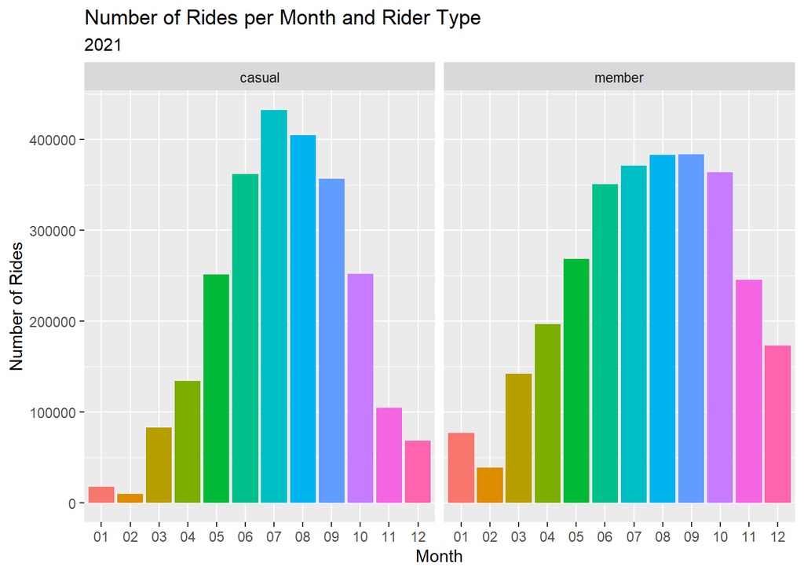

```r
ggplot(number_rides, aes(x = m_n, y = n, fill = m_n)) +
  geom_col(show.legend = FALSE) +
  facet_wrap(~member_casual) +
  labs(title = 'Number of Rides per Month and Rider Type', subtitle = '2021', x = 'Month', y = 'Number of Rides')
```

Here we can see that the number of rides is bigger during the warmer months, and that, except for the summer, member rides are more frequent than casual rides.

2. The next dataset contains the number of rides per weekday, rider and rideable type. I visualized it using a column chart again.

```r
number_rides_day <- totalv2 %>%
  group_by(w, member_casual, rideable_type) %>%
  count(member_casual) %>%
  filter(n > 1)
```

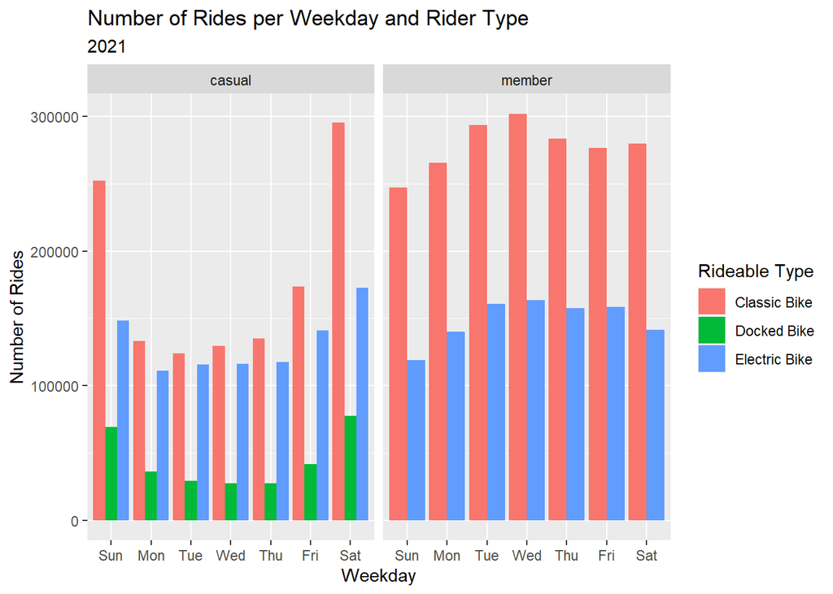

```r
ggplot(number_rides_day, aes(x = w, y = n, fill = rideable_type)) +
  geom_col(position = 'dodge') + facet_wrap(~member_casual) +
  labs(title = 'Number of Rides per Weekday and Rider Type', subtitle = '2021', x = 'Weekday', y = 'Number of Rides') +
  scale_fill_discrete(name = 'Rideable Type', labels = c('Classic Bike', 'Docked Bike', 'Electric Bike'))
```

Here we can see that member rides are level throughout the week, including weekends and peaking on Wednesday, while for casual riders the number of rides during the week is very low compared to the number of rides on weekends, peaking on Saturday. From this we can say that casual riders use the bikes for leisure, while members use them to go to work, as well as for leisure. We can also see that the preferred rideable type for both rider types is the classic bike, followed by the electric bike. However, perhaps the number of classic bikes used is bigger simply because there are more of those available than the others. We do not have enough data to draw conclusions.

3. Number of rides per hour during the week, visualized using a line chart.

```r
number_rides_wk <- totalv2 %>%
  filter(w != 'Sat' & w != 'Sun') %>%
  group_by(h, member_casual, rideable_type) %>%
  count(member_casual) %>%
  filter(n > 1)
```

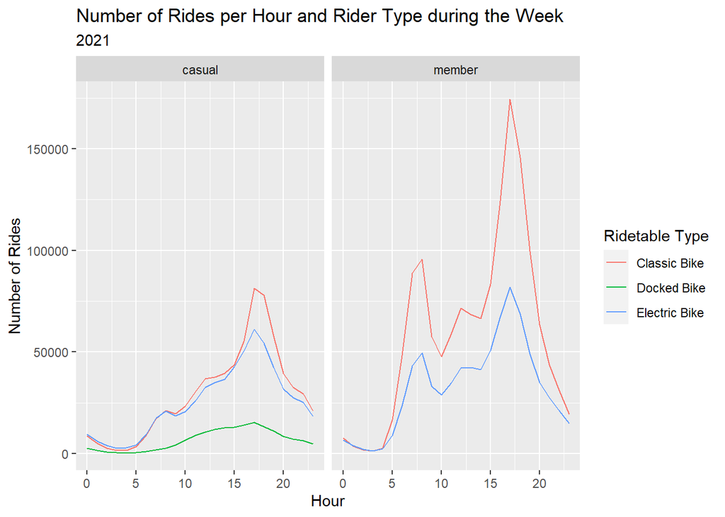

```r
ggplot(number_rides_wk, aes(x = h, y = n, color = rideable_type)) +
  geom_line() + facet_wrap(~member_casual) +
  labs(title = 'Number of Rides per Hour and Rider Type during the Week', subtitle = '2021', x = 'Hour', y = 'Number of Rides') +
  scale_color_discrete(name = 'Ridetable Type', labels = c('Classic Bike', 'Docked Bike', 'Electric Bike'))
```

4. Number of rides per hour on weekends, visualized using a line chart.

```r
number_rides_hour_wnd <- totalv2 %>%
  filter(w == 'Sat' | w =='Sun') %>%
  group_by(member_casual, rideable_type, h) %>%
  count(member_casual) %>%
  filter(n > 1)
```

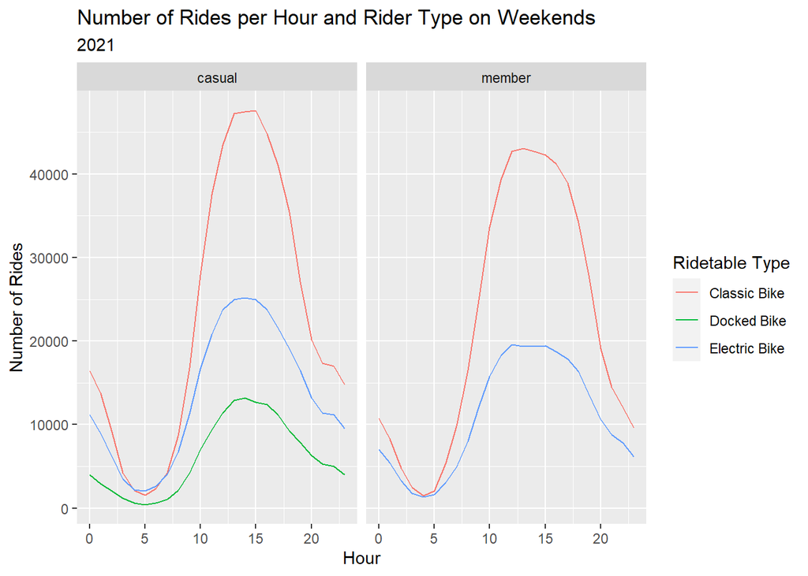

```r
ggplot(number_rides_hour_wnd, aes(x = h, y = n, color = rideable_type)) +
  geom_line() + facet_wrap(~member_casual) +
  labs(title = 'Number of Rides per Hour and Rider Type on Weekends', subtitle = '2021', x = 'Hour', y = 'Number of Rides') +
  scale_color_discrete(name = 'Ridetable Type', labels = c('Classic Bike', 'Docked Bike', 'Electric Bike'))
```

Here we can see that both casual riders and members prefer to go out at noon on weekends.

5. Mean time ride per hour, visualized using a line chart.

```r
time_ride_hour <- totalv2 %>%
  group_by(h, member_casual, rideable_type) %>%
  summarise(mean_tr = mean(time_ride))
```

[figure not shown]

```r
ggplot(time_ride_hour) +
  geom_line(aes(x = h, y = mean_tr, color = rideable_type)) +
  facet_wrap(~member_casual) +
  labs(title = 'Mean Ride Time per Hour and Rider Type', subtitle = '2021', x = 'Hour', y = 'Number of Rides') +
  scale_color_discrete(name = 'Ridetable Type', labels = c('Classic Bike', 'Docked Bike', 'Electric Bike'))
```

Rides with docked bikes last the most and their duration peaks around 3 and 10 AM. Rides with classic bikes last longer than rides with electric bikes. Member rides last considerably less than casual rides, and after 10 AM the duration hardly changes throughout the day.

# Conclusions

- Members continue to use the bikes a considerable amount throughout the year, not just in the summer.
- Members use the bikes during the week, as well as on the weekends. Casual riders use them mostly on weekends.
- Members use the bikes to commute to and from work.
- Members’ rides last less than casual riders’, but are more frequent.